# 学習用RPGの作成(SimpleRPG)

> オブジェクト指向プログラミングおよび演習1 第6回

> テキストベースのシンプルなRPGを作成します。

今回作成するプログラムは、今回と次回の「継承」や「抽象クラス」、「インターフェイス」を学ぶための基礎的なプログラムになります。

いままで学んだクラスやメソッドの書き方を使って、テキストベースのRPGのようなものを作成します。

この仕様に沿ったプログラムのソースコードは、資料として配布いたします。  
ソースコードをこの資料と照らし合わせて良く読んでください。

# RPGの基礎部分を作成する

## 作成するところ

1. 攻撃結果クラスの作成
2. 勇者クラスの作成
   1. 勇者の攻撃メソッド作成
   2. 勇者がダメージを受けるメソッド作成
3. 敵クラスの作成
   1. 敵の攻撃メソッド作成
   2. 敵がダメージを受けるメソッド作成
4. メインクラスの作成
   1. 勇者生成メソッド作成
   2. 敵生成メソッド作成
   3. 勇者クラスの行動メソッド作成
   4. 敵クラスの行動メソッド作成
   5. 勇者と敵キャラの戦闘メソッド作成
   6. メインメソッド作成

## プロジェクト設定

- プロジェクト名
  - `SimpleRPG`
- パッケージ
  - `jp.ac.ait.k00000`

# 詳細仕様

## 攻撃結果クラス (AttackResult.java)

攻撃行動の結果を返すために用意するクラスです。 下記コードを使ってください。※パッケージ構文は、各自のパッケージ名に変更すること

```java
package jp.ac.ait.k00000;
/**
 * 行動後の戻り値
 */
public class AttackResult {
    public static final int BATTLE_END = 1;
    public static final int CONTINUE = 0;
    /**
     * 攻撃によって与えたダメージ
     */
    public int damage = 0;
    /**
     * アクション後の戦闘状態
     * 初期値は継続とする
     */
    public int state = CONTINUE;
}
```

## 勇者クラス (Hero.java)

勇者のステータス、行動を定義するクラス

### フィールド

- `private String name` - 名前
- `private int hp` - 体力
- `private int atk` - 攻撃力
- `private int def` - 防御力
- `private int agi` - 素早さ

### コンストラクタ

- `public Hero(String name, int hp, int atk, int def, int agi)`
  - それぞれ引数の値で初期値セット

### メソッド

#### アクセサメソッド(get○○のみ実装)

- `public String getName()` - 名前を返す
- `public int getHp()` - HPを返す
- `public int getAtk()` - ATKを返す
- `public int getDef()` - DEFを返す
- `public int getAgi()` - AGIを返す

#### 行動制御メソッド

- `public AttackResult attack(Enemy target)`
  - 敵に対して攻撃を行う処理を実装します。
  - 下記与えるダメージの計算式に従って計算されたダメージ量を引数の相手に与えます。
  - 戻り値は、AttackResultのインスタンスを生成し、ダメージ量と戦闘続行かどうかの状態をAttackResultの定数フィールドを使って設定して返します。
- `public boolean receiveDamage(int damage)`
  - 勇者がダメージを受ける。(自分で呼び出さず、敵であるEnemyから呼ばれる)
  - フィールドのhpから引数のダメージ分を減算し、0を下回る場合はhpに0を代入する。  
    戻り値はダメージを受けたあとのHPが0以下の場合trueを返し、戦闘続行不可能とする。

## 敵クラス (Enemy.java)

敵のステータス、行動を定義するクラス

### フィールド

- `private String name` - 名前
- `private int hp` - 体力
- `private int atk` - 攻撃力
- `private int def` - 防御力
- `private int agi` - 素早さ

### コンストラクタ

- `public Enemy(String name, int hp, int atk, int def, int agi)`
  - それぞれ引数の値で初期値セット

### メソッド

#### アクセサメソッド(get○○のみ実装)

- `public String getName()` - 名前を返す
- `public int getHp()` - HPを返す
- `public int getAtk()` - ATKを返す
- `public int getDef()` - DEFを返す
- `public int getAgi()` - AGIを返す

#### 行動制御メソッド

- `public AttackResult attack(Hero target)`
  - 勇者に対して攻撃を行う処理を実装します。
  - 下記の与えるダメージの計算式に従って計算されたダメージ量を引数の相手に与えます。
  - 戻り値は、AttackResultのインスタンスを生成し、ダメージ量と戦闘続行かどうかの状態をAttackResultの定数フィールドを使って設定して返します。
- `public boolean receiveDamage(int damage)`
  - 敵がダメージを受けます。(自分で呼び出さず、勇者であるHeroから呼ばれます)
  - フィールドのhpから引数のダメージ分を減算し、0を下回る場合はhpに0を代入します。  
    戻り値はダメージを受けたあとのHPが0以下の場合trueを返し、戦闘続行不可能とします。

## 与えるダメージの計算式

与えられるダメージ計算は「攻撃を行うオブジェクトの攻撃力」 - 「攻撃されるオブジェクトの防御力 ÷２」を小数点以下切り上げで算出し、ランダムに-3〜+3の変化を持たせた数値をそのままHPに対して減算する形式とします。

プログラム中では以下のように計算を行ってください。

```java
        // 引数の攻撃対象targetに対して与えることのできるダメージを算出
        // 与えるダメージ = 自身の攻撃力 - 敵の防御力 / 2 (小数点以下切り上げ) に、-3〜+3のランダムな値を加算
        int damage = (int)Math.ceil((double)this.getAtk() - (target.getDef() / 2.0))
                + (new java.util.Random().nextInt(7) - 3); // ← −3〜+3のランダムな値
```

小数点以下切り上げの方法は、`Math.ceil()`を使います。

#### キャラクター生成時のパラメータ初期値について

キャラクターのパラメータは、次の表にまとめられた範囲に従いランダムに決定させます。

##### 勇者の場合

| パラメータ | ランダム範囲 |
| --- | --- |
| HP | 80 〜 120 |
| ATK | 8 〜 15 |
| DEF | 8 〜 15 |
| AGI | 8 〜 15 |

##### 敵の場合

| パラメータ | ランダム範囲 |
| --- | --- |
| HP | 50 〜 200 |
| ATK | 10 〜 20 |
| DEF | 5 〜 15 |
| AGI | 10 〜 20 |

## メインクラス(SimpleRPG.java)

mainメソッドを持つクラス  
画面表示や画面からの入力は、すべてこのクラス内で行います。

### フィールド

- `Hero hero`
- `Enemy enemy`

### コンストラクタ

なし

### メソッド

- `Hero createHero()`
  - 勇者を生成して返すメソッド
  - 名前を画面から入力させ、それ以外のパラメータは後述するランダムでのパラメータ決定に従いインスタンスを生成し返します
- `Enemy createEnemy()`
  - メソッド内部に、`final String[] ENEMY_NAMES = {"敵1", "敵2", "敵3", "敵4", "敵5"};` のように敵キャラクターの名前を定めた配列を用意し、敵の名前はこの配列よりランダムで選ばれます。
  - 名前は上記配列からランダムで決定し、それ以外のパラメータは後述するランダムでのパラメータ決定に従いインスタンスを生成し返します
- `boolean heroAction()`
  - 勇者の1回分の行動決定と行動を行わせるメソッド
  - 画面より、攻撃か逃亡かを選択させ、その行動結果を画面に表示します
  - 戻り値は、行動により戦闘続行可否をbooleanで返します
- `boolean enemyAction()`
  - 敵の1回分の攻撃行動を行わせるメソッド（敵は攻撃の行動のみ行います）
  - 戻り値は、行動により戦闘続行可否をbooleanで返します
- `void battleLoop()`
  - 戦闘処理の無限ループを用意します
  - 無限ループ内では、勇者と敵の素早さを比較し行動順序を入れ替え、それぞれの行動を行います
  - 行動により戦闘続行不可能になった場合は、その場で無限ループを抜け、メソッドを終了します
- `public static void main(String[] args)`
  - メインメソッド
  - 下記のフローに従い、上記メソッドを利用してゲームの流れを実装します
- その他必要に応じて追加してもよい

### mainメソッドでの処理の流れ

mainメソッド内でのゲームの進行(主要な部分のみ)は以下のフローに従ってください。

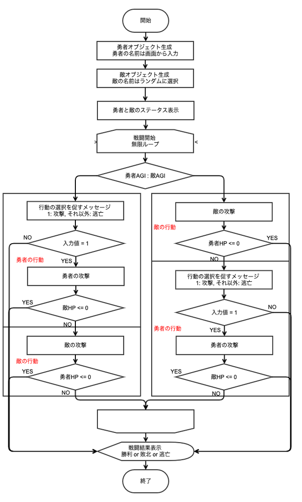

## SimpleRPGの動作確認

今回は、このゲームが動作することを大前提として以降の実習を行います。

サンプルプログラムがアップロードされているので、そちらをダウンロードし、この資料と見比べながらコードを読み、動作確認を行いましょう。